# TensorQTL report

Darren Cameron

2025-09-15

### TensorQTL pipeline steps

We used [tensorQTL](https://github.com/broadinstitute/tensorqtl) to generate eQTL. The citation for tensorQTL is [Taylor-Weiner et al. 2019 (DOI:10.1186/s13059-019-1836-7)](https://genomebiology.biomedcentral.com/articles/10.1186/s13059-019-1836-7).

1. `prep_tensorQTL_input`: Munge cell-specific pseudobulk gExp and covaraiate data into TensorQTL-ready format
2. `zip_pblk_cnts`: bgzip and index pseudobulk gExp data
3. `convert_genotypes`: Convert genotypes into into TensorQTL-ready plink 2 format
4. `split_covariates`: Generate covaraiate files for gene_pc and exp_pc combinations
5. `tensorqtl_nom`: Run TensorQTL nominal
6. `tensorqtl_perm`: Run TensorQTL perm

Settings:

- cis-window: $\pm$ 500kb
- Expression PC covariates tested: 10, 20, 30, 40, 50
- Meta data covariates: PCW, sex
- Genotype PCs: 4 (see genotyping_post_impute_report.html)
- Norm methods tested: bryois, fugita, quantile, xue

#### eQTL plot

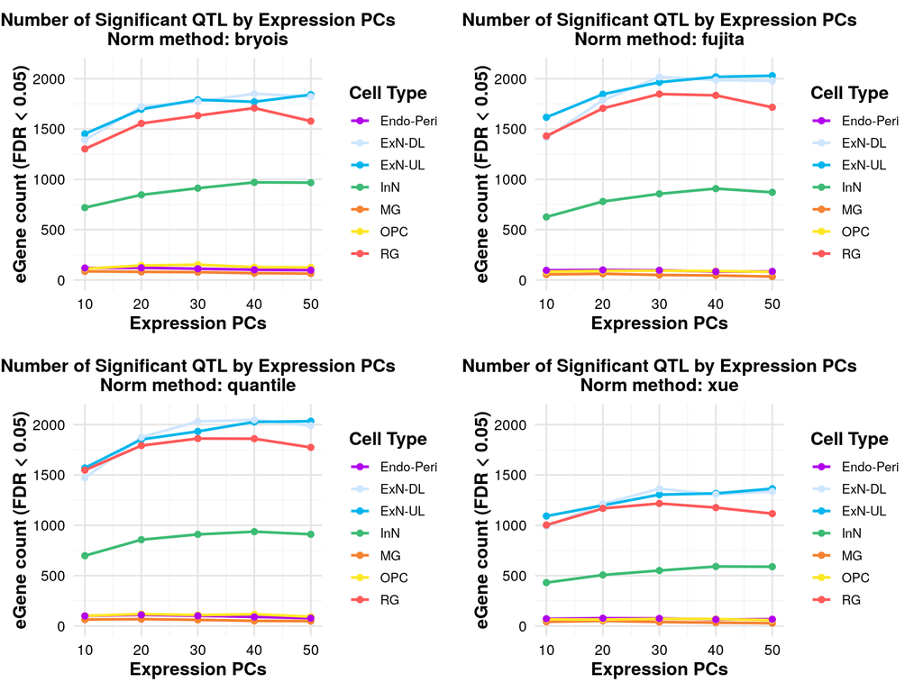

#### Density plot

##### Individual

- Showing plots for geno PCs = 4, Exp PCs = 40, norm method = ‘quantile’

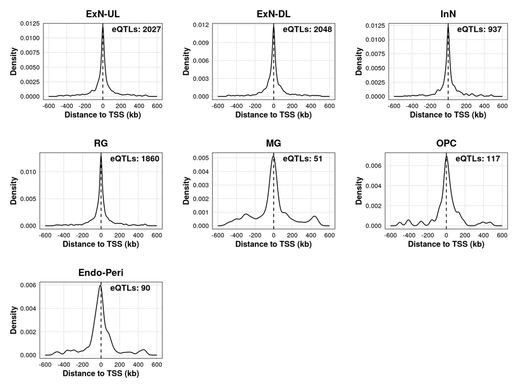

##### Combined

- Showing plots for geno PCs = 4, Exp PCs = 40, norm method = ‘quantile’

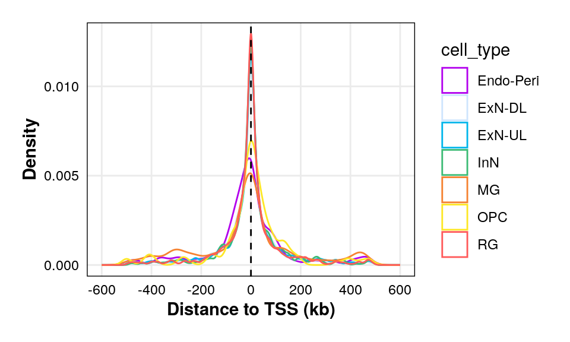

#### Pie Chart

- Showing plots for geno PCs = 4, Exp PCs = 40, norm method = ‘quantile’

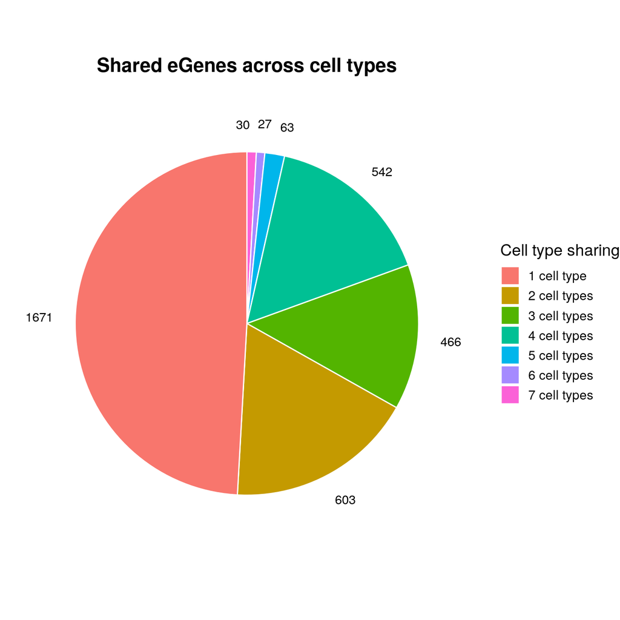

#### Counts

- Showing plots for geno PCs = 4, Exp PCs = 40, norm method = ‘quantile’

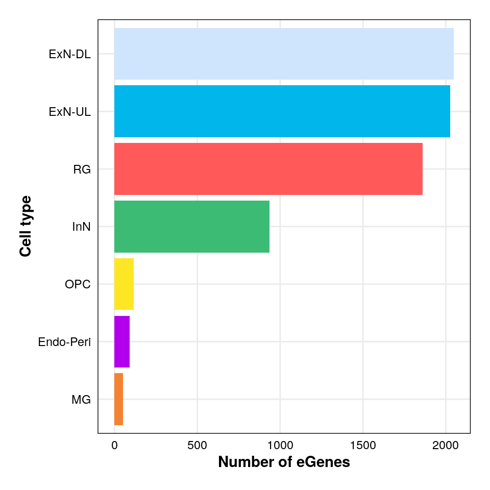

#### Upset

- Showing plots for geno PCs = 4, Exp PCs = 40, norm method = ‘quantile’

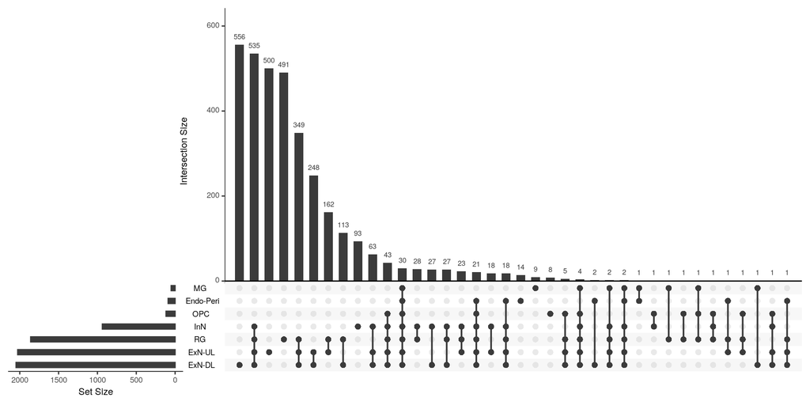

#### Scatter

- Showing plots for geno PCs = 4, Exp PCs = 40, norm method = ‘quantile’

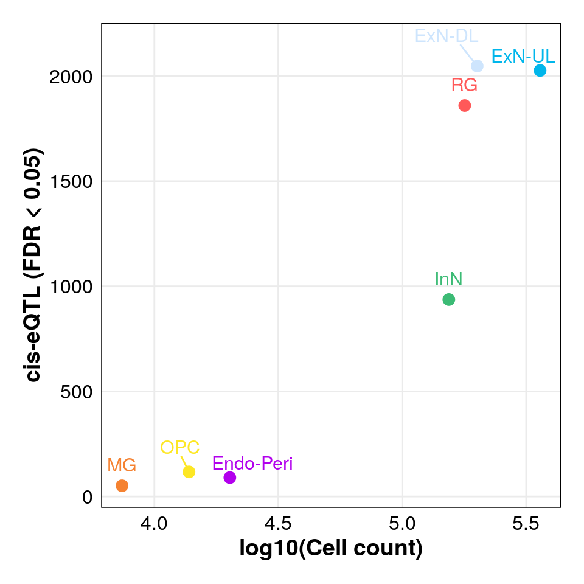

#### Settings

- Showing plots for geno PCs = 4, Exp PCs = 40, norm method = ‘quantile’

Table 1. TensorQTL, inputs per cell type

| Cell Type | Genes Tested | Samples | Variants |
| --- | --- | --- | --- |
| Endo-Peri | 17,361 | 133 | 5,794,957 |
| ExN-DL | 16,332 | 133 | 5,794,957 |
| ExN-UL | 16,083 | 133 | 5,794,957 |
| InN | 16,684 | 133 | 5,794,957 |
| MG | 16,973 | 133 | 5,794,957 |
| OPC | 16,482 | 133 | 5,794,957 |
| RG | 16,835 | 133 | 5,794,957 |

#### Benchmarking

##### Table

|  | rule | n | mean_runtime_min | sd_runtime_min | mean_ram_gb | sd_ram_gb |
| --- | --- | --- | --- | --- | --- | --- |
| 1 | convert | 1 | 1.825 | 0 | 0.879 | 0 |
| 2 | nom | 180 | 3.151 | 0.363 | 3.315 | 0.076 |
| 3 | perm | 180 | 103.736 | 14.535 | 3.414 | 0.096 |
| 4 | prep | 36 | 0.378 | 0.045 | 0.705 | 0.191 |
| 5 | split | 180 | 0.067 | 0.041 | 0.14 | 0.001 |
| 6 | tensorqtl | 1 | 0.637 | 0 | 0.275 | 0 |
| 7 | zip | 36 | 0.069 | 0.016 | 0.017 | 0.004 |

##### Plot

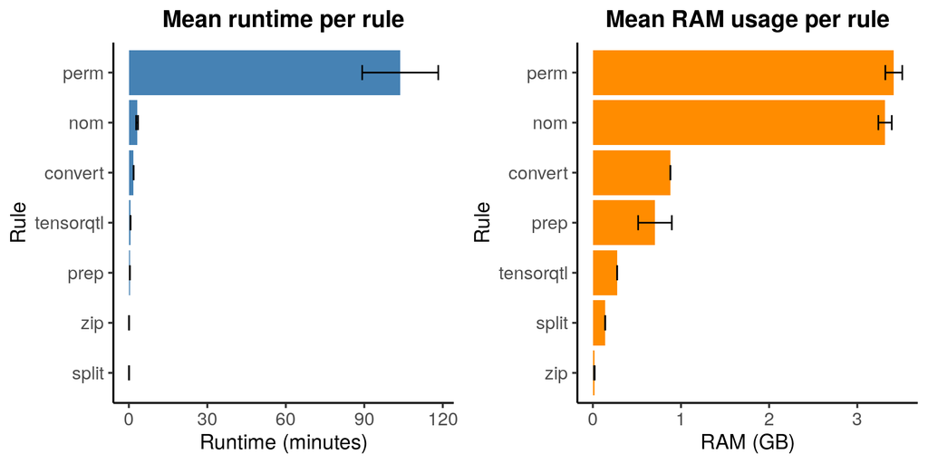